# Credit Card Approval Prediction

# SMOTE

## 4.1 RandomForest Model

```python
## Initialize RandomForest model ##
rf_model_smote = RandomForestClassifier(n_estimators = 500, max_features = 10, min_samples_split = 20, class_weight = 'balanced', random_state=69)

# Train the model
rf_model_smote.fit(X_resampled_smote, y_resampled_smote)

# Predict on the test data-set
y_pred_rf_smote = rf_model_smote.predict(X_test)

# Classification Report
print('Random Forest Classification Report:')
print(classification_report(y_test, y_pred_rf_smote))
```

```
Random Forest Classification Report:
              precision    recall  f1-score   support

           0       0.66      0.68      0.67       291
           1       1.00      1.00      1.00    127393

    accuracy                           1.00    127684
   macro avg       0.83      0.84      0.83    127684
weighted avg       1.00      1.00      1.00    127684
```

Precision, Recall, and F1-score:

- Precision for class 0 (bad debts) is 0.66. This indicates that out of all the instances predicted as class 0, 66% are actually of class 0.
- Recall for class 0 is 0.68, which means that the model correctly identifies 68% of the actual class 0 instances.
- F1-score for class 0 is 0.67.
- Precision, recall, and F1-score for class 1 (good debts) are perfect. The model might overfit the data due to the imbalance.

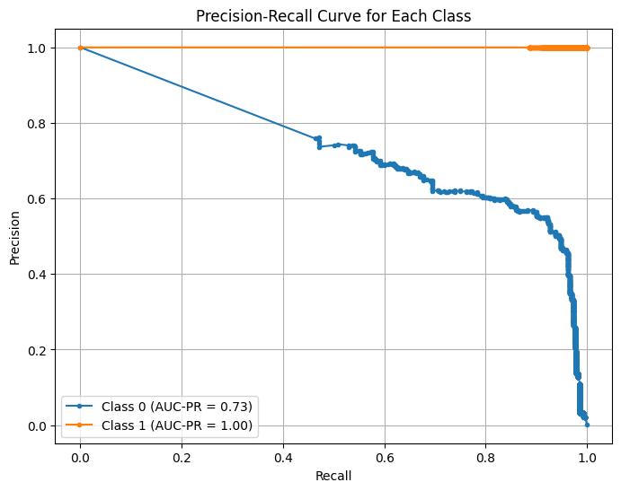

```
AUC-PR for Class 0: 0.73
AUC-PR for Class 1: 1.00
```

```python
## Precision-Recall Curve ##

# Compute probabilities for each class
y_probs = rf_model_smote.predict_proba(X_test)

# Compute precision and recall for each class
precision = dict()
recall = dict()
auc_pr = dict()  # Dictionary to store AUC-PR values
for i in range(len(y_test.unique())):
    precision[i], recall[i], _ = precision_recall_curve(y_test == i, y_probs[:, i])
    auc_pr[i] = auc(recall[i], precision[i])  # Compute AUC-PR for each class

# Plot precision-recall curve for each class
plt.figure(figsize=(8, 6))
for i in range(len(y_test.unique())):
    plt.plot(recall[i], precision[i], marker='.', label=f'Class {i} (AUC-PR = {auc_pr[i]:.2f})')
plt.xlabel('Recall')
plt.ylabel('Precision')
plt.title('Precision-Recall Curve for Each Class')
plt.legend(loc='best')
plt.grid(True)
plt.show()

# Print AUC-PR values for each class
for i in range(len(y_test.unique())):
    print(f"AUC-PR for Class {i}: {auc_pr[i]:.2f}")
```

The Area Under the Precision-Recall curve (AUC-PR) is 0.73 for class 0 and 1 for class 1. This indicates very good performance in terms of precision and recall trade-off, especially for class 1. However, this exceptionally high score might imply overfitting due to imbalanced data.

```python
## Compute confusion_matrix,  False Positives(FP),  False Negatives(FN), False Positive Rate(FPR), False Negative Rate(FNR) ##

# Compute confusion matrix
conf_matrix = confusion_matrix(y_test, y_pred_rf_smote)
print("Confusion Matrix:")
print(conf_matrix)

# Calculate the False Positive Rate and False Negative Rate
# Since the positive label is 0 (bad debt, what we care about), the layout of the confusion matrix is slightly different
# Note: It is assumed that the positive class label is 0 (bad debt) and the negative class label is 1 (good debt)
# We hope to decrease FP (FPR), since it means we predict some applicant 1 (good debt) when actually he/she will be 0 (bad debt)
TP, FN, FP, TN = conf_matrix.ravel()

# False Positive Rate (FPR) = FP / (FP + TN)
FPR = FP / (FP + TN)

# False Negative Rate (FNR) = FN / (FN + TP)
FNR = FN / (FN + TP)

print(f"False Positive Rate: {FPR}")
print(f"False Negative Rate: {FNR}")
```

```
Confusion Matrix:
[[   197     94]
 [   103 127290]]
False Positive Rate: 0.0008085216613157709
False Negative Rate: 0.3230240549828179
```

```python
## Compute Mean Square Error (MSE), R^2 and accuracy of the model ##
mse = mean_squared_error(y_test, y_pred_rf_smote)
r_squared = r2_score(y_test, y_pred_rf_smote)
accuracy = accuracy_score(y_test, y_pred_rf_smote)

print(f"Mean Squared Error: {mse}")
print(f"R^2: {r_squared}")
print("Accuracy:", accuracy)
```

```
Mean Squared Error: 0.0015428714639265687
R^2: 0.3214776591839905
Accuracy: 0.9984571285360734
```

```python
# Compute MDI (Mean Decrease in Impurity) Feature Importance
feature_importances_mdi = rf_model_smote.feature_importances_
mdi_importances = pd.Series(feature_importances_mdi, index=feature_names_encoded)
mdi_importances = mdi_importances.sort_values(ascending=False)

print("Feature importances using Mean Decrease in Impurity (MDI):")
print(mdi_importances)
```

```
Feature importances using Mean Decrease in Impurity (MDI):
remainder__Employment Start                               0.162230
remainder__Days of Birth                                  0.149019
remainder__Months on Book                                 0.127805
remainder__Annual Income                                  0.079702
remainder__Family Size                                    0.038437
remainder__Children                                       0.031319
encoder__Gender_M                                         0.028125
encoder__Income Category_Working                          0.026856
encoder__Income Category_Commercial associate             0.026183
encoder__Gender_F                                         0.024860
encoder__Car_N                                            0.020435
encoder__Car_Y                                            0.020301
encoder__Education Level_Secondary / secondary special    0.018956
encoder__Occupation_Laborers                              0.018582
encoder__Education Level_Higher education                 0.016781
encoder__Property_Y                                       0.016027
encoder__Property_N                                       0.014799
encoder__Occupation_Sales staff                           0.014264
encoder__Marital Status_Civil marriage                    0.013849
encoder__Occupation_Managers                              0.012988
encoder__Marital Status_Single / not married              0.012332
encoder__Occupation_Core staff                            0.012036
encoder__Occupation_High skill tech staff                 0.011899
encoder__Occupation_Drivers                               0.011865
encoder__Marital Status_Married                           0.010200
encoder__Occupation_Low-skill Laborers                    0.008308
encoder__Occupation_Security staff                        0.008111
encoder__Housing Type_House / apartment                   0.007532
encoder__Income Category_State servant                    0.006722
encoder__Education Level_Lower secondary                  0.006208
encoder__Marital Status_Separated                         0.005991
encoder__Education Level_Incomplete higher                0.005700
encoder__Housing Type_Municipal apartment                 0.005222
encoder__Housing Type_Co-op apartment                     0.004714
encoder__Occupation_Cooking staff                         0.004464
encoder__Occupation_Medicine staff                        0.003905
encoder__Marital Status_Widow                             0.003069
encoder__Occupation_Accountants                           0.002710
encoder__Housing Type_With parents                        0.002064
encoder__Housing Type_Rented apartment                    0.001874
encoder__Occupation_Cleaning staff                        0.001441
encoder__Income Category_Pensioner                        0.000818
encoder__Occupation_Secretaries                           0.000481
encoder__Housing Type_Office apartment                    0.000418
encoder__Occupation_Private service staff                 0.000220
encoder__Occupation_HR staff                              0.000050
encoder__Education Level_Academic degree                  0.000042
encoder__Occupation_Realty agents                         0.000036
encoder__Occupation_Waiters/barmen staff                  0.000034
encoder__Income Category_Student                          0.000009
encoder__Occupation_IT staff                              0.000007
dtype: float64
```

- Features like "Employment Start," "Days of Birth," and "Months on Book" have relatively high importance according to MDI, suggesting they play a significant role in the classification process.
- Features related to demographic information such as gender, income category, marital status, and education level also have noticeable importance.

## 4.2 XGBoost

```python
# Initialize the XGBoost Classifier
xgb_model_smote = xgb.XGBClassifier(subsample=0.8, n_estimators=600, min_child_weight=30, max_depth=13, learning_rate=0.2, colsample_bytree=1)

# Fit model to the data
xgb_model_smote.fit(X_resampled_smote, y_resampled_smote)

# Predict on the test data-set
y_pred_xgb_smote = xgb_model_smote.predict(X_test)

# Classification Report
print("XGBoost Classification Report:")
print(classification_report(y_test, y_pred_xgb_smote))
```

```
XGBoost Classification Report:
              precision    recall  f1-score   support

           0       0.55      0.89      0.68       291
           1       1.00      1.00      1.00    127393

    accuracy                           1.00    127684
   macro avg       0.77      0.94      0.84    127684
weighted avg       1.00      1.00      1.00    127684
```

Precision, Recall, and F1-score:

- Precision for class 0 (bad debts) is 0.55. This indicates that out of all instances predicted as class 0, 55% are actually of class 0.
- Recall for class 0 is 0.89, implying that the model correctly identifies 89% of the actual class 0 instances.
- F1-score for class 0 is 0.68.
- Precision, recall, and F1-score for class 1 (good debts) are perfect, indicating that the model performs exceptionally well in identifying class 1 instances. However, this could imply that the model is overfitting the data due to high imbalance.

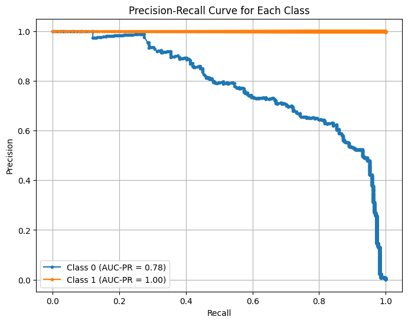

```
AUC-PR for Class 0: 0.78
AUC-PR for Class 1: 1.00
```

```python
## Precision-Recall Curve ##

# Compute probabilities for each class
y_probs = xgb_model_smote.predict_proba(X_test)

# Compute precision and recall for each class
precision = dict()
recall = dict()
auc_pr = dict()  # Dictionary to store AUC-PR values
for i in range(len(y_test.unique())):
    precision[i], recall[i], _ = precision_recall_curve(y_test == i, y_probs[:, i])
    auc_pr[i] = auc(recall[i], precision[i])  # Compute AUC-PR for each class

# Plot precision-recall curve for each class
plt.figure(figsize=(8, 6))
for i in range(len(y_test.unique())):
    plt.plot(recall[i], precision[i], marker='.', label=f'Class {i} (AUC-PR = {auc_pr[i]:.2f})')
plt.xlabel('Recall')
plt.ylabel('Precision')
plt.title('Precision-Recall Curve for Each Class')
plt.legend(loc='best')
plt.grid(True)
plt.show()

# Print AUC-PR values for each class
for i in range(len(y_test.unique())):
    print(f"AUC-PR for Class {i}: {auc_pr[i]:.2f}")
```

- The Area Under the Precision-Recall curve (AUC-PR) is 0.78 for class 0 and 1 for class 1. This indicates very good performance in terms of precision and recall trade-off, especially for class 1. However, the perfect score might indicate overfit due to imbalance.

```python
## Compute confusion_matrix,  False Positives(FP),  False Negatives(FN), False Positive Rate(FPR), False Negative Rate(FNR) ##
# So we want to control **FP**, which means predict some applicant to be 1 (good debt) when actually he/she is in 0 (bad debt))

# Compute confusion matrix
conf_matrix = confusion_matrix(y_test, y_pred_xgb_smote)
print("Confusion Matrix:")
print(conf_matrix)

# Calculate the False Positive Rate and False Negative Rate
# Since the positive label is 0 (bad debt, what we care about), the layout of the confusion matrix is slightly different
# Note: It is assumed that the positive class label is 0 (bad debt) and the negative class label is 1 (good debt)
# We hope to decrease FP (FPR), since it means we predict some applicant 1 (good debt) when actually he/she will be 0 (bad debt)
TP, FN, FP, TN = conf_matrix.ravel()

# False Positive Rate (FPR) = FP / (FP + TN)
FPR = FP / (FP + TN)

# False Negative Rate (FNR) = FN / (FN + TP)
FNR = FN / (FN + TP)

print(f"False Positive Rate: {FPR}")
print(f"False Negative Rate: {FNR}")
```

```
Confusion Matrix:
[[   259     32]
 [   214 127179]]
False Positive Rate: 0.001679841121568689
False Negative Rate: 0.10996563573883161
```

```python
## Compute Mean Square Error (MSE), R^2 and accuracy of the model ##
mse = mean_squared_error(y_test, y_pred_xgb_smote)
r_squared = r2_score(y_test, y_pred_xgb_smote)
accuracy = accuracy_score(y_test, y_pred_xgb_smote)

print(f"Mean Squared Error: {mse}")
print(f"R^2: {r_squared}")
print("Accuracy:", accuracy)
```

```
Mean Squared Error: 0.0019266313711976443
R^2: 0.15270814294041457
Accuracy: 0.9980733686288024
```

```python
# Compute MDI (Mean Decrease in Impurity) Feature Importance
feature_importances_mdi = xgb_model_smote.feature_importances_
mdi_importances = pd.Series(feature_importances_mdi, index=feature_names_encoded)
mdi_importances = mdi_importances.sort_values(ascending=False)

print("Feature importances using Mean Decrease in Impurity (MDI):")
print(mdi_importances)
```

```
Feature importances using Mean Decrease in Impurity (MDI):
encoder__Education Level_Incomplete higher                0.105234
encoder__Income Category_Commercial associate             0.081063
encoder__Occupation_Private service staff                 0.072621
encoder__Occupation_Core staff                            0.052185
encoder__Occupation_Drivers                               0.047949
encoder__Housing Type_Municipal apartment                 0.038688
encoder__Car_Y                                            0.035746
encoder__Car_N                                            0.035423
remainder__Family Size                                    0.034763
encoder__Occupation_Cleaning staff                        0.030518
encoder__Marital Status_Civil marriage                    0.029864
encoder__Housing Type_Co-op apartment                     0.029647
encoder__Income Category_Working                          0.029341
encoder__Housing Type_Office apartment                    0.025845
remainder__Days of Birth                                  0.025200
remainder__Employment Start                               0.025041
encoder__Occupation_Low-skill Laborers                    0.023838
remainder__Children                                       0.022571
encoder__Property_Y                                       0.019966
remainder__Annual Income                                  0.019868
encoder__Marital Status_Single / not married              0.019551
encoder__Marital Status_Separated                         0.019512
encoder__Occupation_Medicine staff                        0.019471
encoder__Gender_F                                         0.019177
encoder__Occupation_Managers                              0.013878
encoder__Occupation_Sales staff                           0.013490
encoder__Occupation_Laborers                              0.011055
encoder__Housing Type_House / apartment                   0.010869
encoder__Occupation_High skill tech staff                 0.009240
encoder__Education Level_Higher education                 0.009029
encoder__Education Level_Secondary / secondary special    0.008374
encoder__Housing Type_Rented apartment                    0.007558
remainder__Months on Book                                 0.007319
encoder__Occupation_Accountants                           0.007316
encoder__Income Category_State servant                    0.006179
encoder__Marital Status_Married                           0.005911
encoder__Property_N                                       0.005859
encoder__Occupation_Cooking staff                         0.005748
encoder__Marital Status_Widow                             0.004107
encoder__Housing Type_With parents                        0.003840
encoder__Gender_M                                         0.003130
encoder__Education Level_Lower secondary                  0.002356
encoder__Occupation_Security staff                        0.001660
encoder__Occupation_Secretaries                           0.000000
encoder__Occupation_Waiters/barmen staff                  0.000000
encoder__Education Level_Academic degree                  0.000000
encoder__Income Category_Student                          0.000000
encoder__Occupation_Realty agents                         0.000000
encoder__Income Category_Pensioner                        0.000000
encoder__Occupation_IT staff                              0.000000
encoder__Occupation_HR staff                              0.000000
dtype: float32
```

- Features like "Education Level," "Income Category," and "Occupation" have relatively high importance, suggesting they play a significant role in the classification process.
- Demographic features such as marital status, housing type, and gender also appear to be important.

## 4.3 LightGBM

```python
# Initialize the LightGBM Classifier
lgb_model_smote = lgb.LGBMClassifier(num_leaves=40, n_estimators=700, min_child_samples=250, max_depth=10, learning_rate=0.05, feature_fraction=0.8)

# Fit model to the data
lgb_model_smote.fit(X_resampled_smote, y_resampled_smote)

# Predict on the test data-set
y_pred_lgb_smote = lgb_model_smote.predict(X_test)

# Classification Report
print("LightGBM Classification Report:")
print(classification_report(y_test, y_pred_lgb_smote))
```

```
[LightGBM] [Warning] feature_fraction is set=0.8, colsample_bytree=1.0 will be ignored. Current value: feature_fraction=0.8
[LightGBM] [Warning] feature_fraction is set=0.8, colsample_bytree=1.0 will be ignored. Current value: feature_fraction=0.8
[LightGBM] [Info] Number of positive: 297242, number of negative: 297242
[LightGBM] [Info] Auto-choosing row-wise multi-threading, the overhead of testing was 0.310804 seconds.
You can set `force_row_wise=true` to remove the overhead.
And if memory is not enough, you can set `force_col_wise=true`.
[LightGBM] [Info] Total Bins 9781
[LightGBM] [Info] Number of data points in the train set: 594484, number of used features: 50
[LightGBM] [Info] [binary:BoostFromScore]: pavg=0.500000 -> initscore=0.000000
[LightGBM] [Warning] feature_fraction is set=0.8, colsample_bytree=1.0 will be ignored. Current value: feature_fraction=0.8
LightGBM Classification Report:
              precision    recall  f1-score   support

           0       0.62      0.84      0.71       291
           1       1.00      1.00      1.00    127393

    accuracy                           1.00    127684
   macro avg       0.81      0.92      0.86    127684
weighted avg       1.00      1.00      1.00    127684
```

Precision, Recall, and F1-score:

- Precision for class 0 (bad debts) is 0.62. This indicates that out of all instances predicted as class 0, 62% are actually of class 0.
- Recall for class 0 is 0.84, suggesting that the model correctly identifies 84% of the actual class 0 instances.
- F1-score for class 0 is 0.71.
- Precision, recall, and F1-score for class 1 (good debts) are perfect, indicating that the model performs exceptionally well in identifying class 1 instances. However, this could imply overfit due to the imbalance.

```
[LightGBM] [Warning] feature_fraction is set=0.8, colsample_bytree=1.0 will be ignored. Current value: feature_fraction=0.8
```

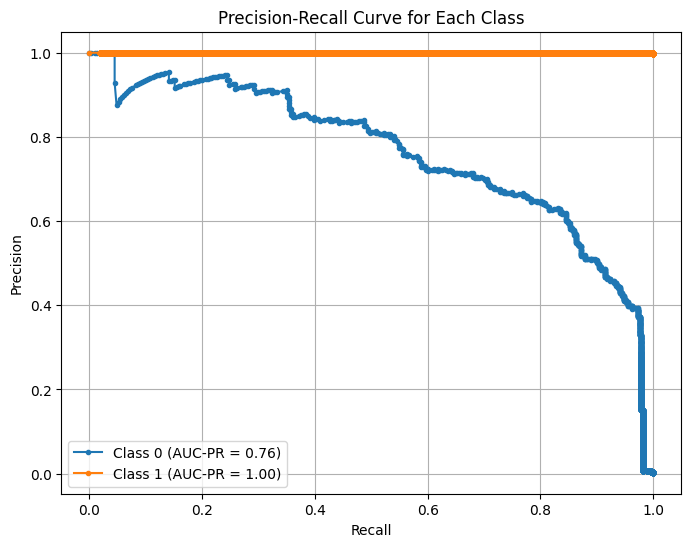

```
AUC-PR for Class 0: 0.76
AUC-PR for Class 1: 1.00
```

```python
## Precision-Recall Curve ##

# Compute probabilities for each class
y_probs = lgb_model_smote.predict_proba(X_test)

# Compute precision and recall for each class
precision = dict()
recall = dict()
auc_pr = dict()  # Dictionary to store AUC-PR values
for i in range(len(y_test.unique())):
    precision[i], recall[i], _ = precision_recall_curve(y_test == i, y_probs[:, i])
    auc_pr[i] = auc(recall[i], precision[i])  # Compute AUC-PR for each class

# Plot precision-recall curve for each class
plt.figure(figsize=(8, 6))
for i in range(len(y_test.unique())):
    plt.plot(recall[i], precision[i], marker='.', label=f'Class {i} (AUC-PR = {auc_pr[i]:.2f})')
plt.xlabel('Recall')
plt.ylabel('Precision')
plt.title('Precision-Recall Curve for Each Class')
plt.legend(loc='best')
plt.grid(True)
plt.show()

# Print AUC-PR values for each class
for i in range(len(y_test.unique())):
    print(f"AUC-PR for Class {i}: {auc_pr[i]:.2f}")
```

The Area Under the Precision-Recall curve (AUC-PR) is 0.76 for class 0 and 1 for class 1. This indicates very good performance in terms of precision and recall trade-off, especially for class 1. However, the perfect score might imply overfitting due to imbalance.

```python
## Compute confusion_matrix,  False Positives(FP),  False Negatives(FN), False Positive Rate(FPR), False Negative Rate(FNR) ##
# So we want to control **FP**, which means predict some applicant to be 1 (good debt) when actually he/she is in 0 (bad debt))

# Compute confusion matrix
conf_matrix = confusion_matrix(y_test, y_pred_lgb_smote)
print("Confusion Matrix:")
print(conf_matrix)

# Calculate the False Positive Rate and False Negative Rate
# Since the positive label is 0 (bad debt, what we care about), the layout of the confusion matrix is slightly different
# Note: It is assumed that the positive class label is 0 (bad debt) and the negative class label is 1 (good debt)
# We hope to decrease FP (FPR), since it means we predict some applicant 1 (good debt) when actually he/she will be 0 (bad debt)
TP, FN, FP, TN = conf_matrix.ravel()

# False Positive Rate (FPR) = FP / (FP + TN)
FPR = FP / (FP + TN)

# False Negative Rate (FNR) = FN / (FN + TP)
FNR = FN / (FN + TP)

print(f"False Positive Rate: {FPR}")
print(f"False Negative Rate: {FNR}")
```

```
Confusion Matrix:
[[   244     47]
 [   149 127244]]
False Positive Rate: 0.0011696090052043676
False Negative Rate: 0.16151202749140894
```

```python
## Compute Mean Square Error (MSE), R^2 and accuracy of the model ##
mse = mean_squared_error(y_test, y_pred_lgb_smote)
r_squared = r2_score(y_test, y_pred_lgb_smote)
accuracy = accuracy_score(y_test, y_pred_lgb_smote)

print(f"Mean Squared Error: {mse}")
print(f"R^2: {r_squared}")
print("Accuracy:", accuracy)
```

```
Mean Squared Error: 0.0015350396290843018
R^2: 0.3249219350256962
Accuracy: 0.9984649603709157
```

Random Forest with SMOTE:

- Achieved perfect precision, recall, and F1-score for class 1 (good debts).
- Struggled with precision, recall, and F1-score for class 0 (bad debts), indicating potential issues with handling the minority class.
- Moderate AUC-PR for class 0 (0.73) and perfect AUC-PR for class 1.
- High false negative rate (0.32) indicates significant misclassification of class 0 instances.

XGBoost with SMOTE:

- Achieved perfect precision, recall, and F1-score for class 1 (good debts).
- Similar to Random Forest, struggled with precision, recall, and F1-score for class 0 (bad debts).
- Moderate AUC-PR for class 0 (0.78) and perfect AUC-PR for class 1.
- Relatively lower false negative rate (0.11) compared to Random Forest.

LightGBM with SMOTE: